# Demonstration of analysis features of NUSENSI

#### CR 12/15

#### Note: Run analysis steps either with ipython notebook server which can be started via 'ipython notebook' or in ipython interactive window started with 'ipython --pylab --profile=numpy'

##### Abstract

To calculate sensitivity factors, e.g. $S_{ij}$ for isotope $i$ and rate $j$ in form of a matrix the script sensitivity.py is used in the following. For the analysis the results from the rate modifications and a reference run (without any modifications) is needed. The results in the path_results dir (after performing runs, see nusensi.input) can be easily used. Additionaly one can calculate the errors of each sensitivity factor by taking into account the errors from rates specified in errors.txt. Furthermore plot_sens.py is used to visualize the sensitivity with a isotopic chart.

```python
#import modules
import sensitivity as sens
import plot_sens as ps
%pylab nbagg
```

### Read run with default rates

```python
runs=sens.read_ref_run(cycle=125,path='../run_r45f1.0')
```

```
1 cycle numbers found in ../run_r45f1.0
Ranging from 0 to 0
1 cycle numbers found in ../run_r45f1.0
Ranging from 0 to 0
```

### Create the sensitivity matrix

```python
runs.sens_matrix(path_results=["../results/"],factors=[1.1],
                 filename='sensitivity_matrix.txt',decay=False,abu_threshold=1e-9)
```

```
Found  ['run_r45f1.1']
1 cycle numbers found in ../results//run_r45f1.1
Ranging from 0 to 0
Calling get method in cycle mode, adding a_iso_to_plot, z.. el.. isotope.. isotope... to instance
WARNING: decayed in _getcycle ignores isomers and will decay alpha-unstable p-rich nuclei as if they were beta+ stable.
Initialising decay index pointers ....
Th does not exist in this run
U does not exist in this run
Can't find element Th in isotopedatabase.txt
Created sensitivity matrix in file sensitivity_matrix.txt
```

Voila! Now have a look at the file 'sensitivity_matrix.txt'. See the docstring of the function calc_matrix for a explanation about the structure.

## Plot sensitivities

### Read in matrix

```python
m1=ps.plot_sens('sensitivity_matrix.txt')
```

### Create chart plot

```
found rate
```

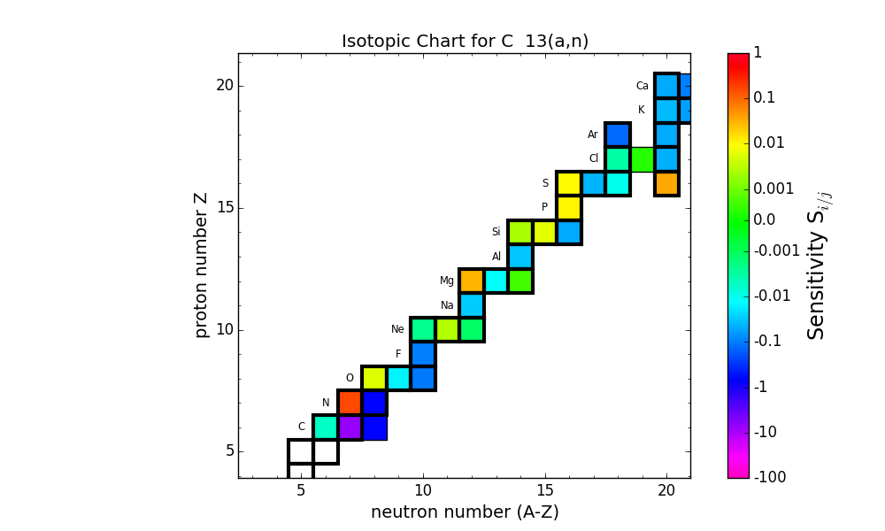

```python
m1.abu_chart(ifig=111,sens_param_type='reaction',sens_param='C  13(a,n)')
```